# RandomForestFinal

2025-11-03

```r
#load packages


library(here)
library(dplyr)
library(tidyr) #for pivoting
library(randomForest)
library(caret)
```

# 1. Introduction

The use of decision trees is both simple and intuitive. They provide a straight forward, visual way to represent how different variables influence a certain outcome by splitting data into small groups based on predictor values. However, single decision trees can be unstable and sensitive to training data. This problem is referred to as over-fitting, where a model performs well on known data but poorly on unseen data. And so minor changes in the dataset can lead to major changes in the predicted outcomes. Hence this makes them inefficient when generalising new, unseen data .

Random Forest trees presents a way of overcoming these issues. The idea is that they combine the predictions of many single decision trees into one robust and accurate model. Instead of relying on a single tree, a Random Forest builds multiple trees using different samples of the data and random subsets of features at each split. The results from all trees are then averaged (for regression) or voted on (for classification) to generate the final prediction.

With this in mind, we can confidently say that this model will be highly appropriate for our aim of predicting PM10 concentrations across European cities. Data regarding air quality is complex. It can contain non-linear patterns, interactions between pollutants and regional differences. A single regression model may struggle to capture these elements, but Random Forests can adapt to these complexities without requiring strong assumptions about the data’s structure.

reference: [1] “https://www.ibm.com/think/topics/random-forest”

# 2. Data Preparation

```r
who_data <- read.csv(here("GracieBelmonte","data","who_data.csv"))


europe_data= who_data %>%
  filter(who_region=="4_Eur")%>%
  select(-iso3, -pm10_tempcov, -pm25_tempcov,-who_region,-no2_tempcov, -type_of_stations)%>%
  filter(!is.na(pm10_concentration)) # drop the missing values of the row we are predicting


set.seed(2)

#for models that include missing data
#split training and test data
train_index <- sample(seq_len(nrow(europe_data)), size = 0.9 * nrow(europe_data)) #creating a 90-10 split
train_data <- europe_data[train_index, ]
test_data  <- europe_data[-train_index, ]


#USE CROSS VALIDATION
# Define formula

rf_formula <- pm10_concentration ~ pm25_concentration + no2_concentration +
               population + latitude + longitude


# 10 fold cross validation step
set.seed(123)
train_control <- trainControl(method = "cv", number = 10)


train_cv= trainControl(method = "cv",number=10)
```

The key variables retained were:

- `pm10_concentration` - the target variable to be predicted.
- `pm25_concentration`, no2_concentration`,`population`,`longitude`and`latitude` - predictor variables.
- `country_name`, `city` and `year` - identifying variables.

# 3. Train the Random Forest Model

This section implemented the Random Forest algorithm, adapted from: [2] “https://www.statology.org/random-forest-in-r/”

- The algorithm automatically handled missing values using the `na.roughfix` function that was found from : [3] ’https://stackoverflow.com/questions/8370455/how-to-use-random-forests-in-r-with-missing-values”
- The default of 500 decision trees was used.
- When building each tree, the `randomForest` algorithm only considers a random subset of the available predictors at each split.
- This randomness prevents dominant predictors, for example `pm25_concentration` from being used in every tree, and thus skewing results.
- The final prediction is the average of all the trees’ output.

```r
library(randomForest)

set.seed(123)
rf_model <- randomForest(
  formula = rf_formula,
  data = train_data, # this will need the whole 90% train data
  na.action = na.roughfix,  # automatically handles missing predictors
  trControl = train_control
)

rf_model
```

```
##
## Call:
##  randomForest(formula = rf_formula, data = train_data, trControl = train_control,      na.action = na.roughfix)
##                Type of random forest: regression
##                      Number of trees: 500
## No. of variables tried at each split: 1
##
##           Mean of squared residuals: 28.80199
##                     % Var explained: 78.49
```

# 4. Visualising our predictions

- In this section, the fitted Random Forest model is used to **predict PM10 concentrations** .
- This procedure again uses code from:[2]“https://www.statology.org/random-forest-in-r/”

```r
#making our predictions

# use the fitted Random Forest model to predict PM10 values for 2021
predictions <- predict(rf_model, newdata = test_data)

# add the predicted PM10 values to the test dataset
test_data$predicted_pm10 <- predictions

#head(test_data)
```

- The `predict()` function in R takes the fitted Random Forest model object (`rf_model`) and applies it new data (`test_data`).
- `test_data\$predicted_pm10 \<- predictions` creates a new variable within ‘test_data’ data-frame that stores the model’s predicted PM10 values.

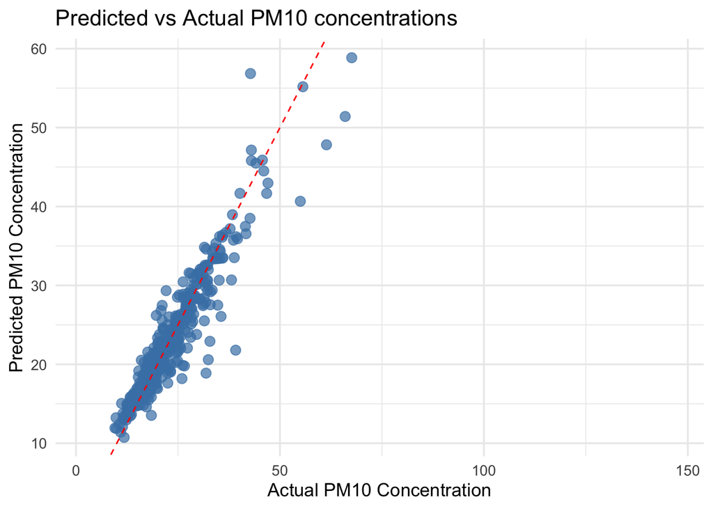

```r
# load ggplot2 for graphs

library(ggplot2)

#scatter plot of predicted vs actual PM10
ggplot(test_data, aes( x = pm10_concentration, y = predicted_pm10)) +
  geom_point(colour = "steelblue", size = 3, alpha = 0.7) +
  geom_abline(slope= 1, intercept = 0, colour= "red", linetype = "dashed") +
  labs(
    title = "Predicted vs Actual PM10 concentrations ",
    x = "Actual PM10 Concentration",
    y = "Predicted PM10 Concentration"
  ) +
  theme_minimal(base_size = 13)
```

### Comments on the scatter plot

- The majority of the points cluster closely around the red line (perfect prediction line), suggesting a good alignment of the predicted and observed values.
- This indicates that the Random Forest model successfully captures the key relationships between PM10 and the predictor variables.
- The tightness of the spread represents a low overall error, however there are a few outliers present for the higher pollution levels.
- These high pollution levels are predicted less accurately, likely because such extreme pollution levels are under-represented in the training data.
- Overall, this is a good plot and shows a strong predictive performance of the Random Forest model.

# 5. Evaluate Model Preformance with a metric

In order to assess the performance of my chosen model submission, the Random Forest model, our group has chosen to use the **Root Mean Squared Error (RSME)**.

We have implemented this using code adapted from:[4] “https://stackoverflow.com/questions/60685866/how-do-i-find-out-the-rmse-of-a-random-forest-in-r”

```r
RSME <- sqrt(mean((test_data$pm10_concentration - test_data$predicted_pm10)^2, na.rm = TRUE))

cat("Root Mean Squared Error (RMSE):", round(RSME, 3), "\n")
```

```
## Root Mean Squared Error (RMSE): 2.826
```

- The value of **2.826** tells us that, on average, the Random Forest’s predicted PM10 concentrations differ from the true observed values by about **2.8$\mu g/m^3$**.
- Given that the typical range of PM10 concentrations across Europe regions is often between 10-40$\mu g/m^3$, a value of 2.83 is a relatively small error.
- This results supports the visual evidence from the scatter plot, confirming that the model’s performance is strong and reliable.

# 6. Analyse Feature Importance

A useful strength of the Random Forest model is that they can provide a direct measure of **feature Importance**, in other words, quantifying how much each variable contributed to the models prediction.

This is calculated using how much each variable reduces the model’s prediction error across all trees in the forest. We used code adapted from [5]“https://stats.stackexchange.com/questions/153663/how-to-get-the-most-important-variables-in-random-forests-in-r”)

```r
# extract feature importance from the Random Forest Model

importance_df <- importance(rf_model) %>%
  data.frame() %>%
  mutate(Feature = rownames(.))


#Display
colnames(importance_df)
```

```
## [1] "IncNodePurity" "Feature"
```

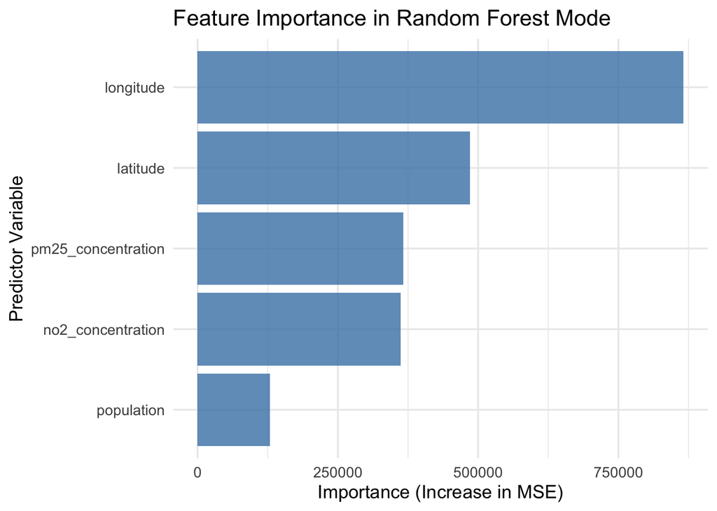

```r
#Plot Feature Importance
library(ggplot2)

ggplot(importance_df,aes(x = reorder(Feature, IncNodePurity), y = IncNodePurity)) +
  geom_bar(stat = "identity", fill = "steelblue", alpha = 0.8) +
  coord_flip()+
  labs(
    title = "Feature Importance in Random Forest Mode",
    x = "Predictor Variable",
    y = "Importance (Increase in MSE)"
  ) +
  theme_minimal(base_size = 13)
```

## Discussion of the graph

- The x-axis represents the importance score `IncNodePurity`, which is the amount each variable improves the model’s ability to make accurate splits across all trees in the Random Forest.
- The y-axis lists the predictors: `longitude`, `latitude`, `pm25_concentration`, `no2_concentration` and `population`.

### Interpretation

- `Longitude` was the most influential variable, the model relies heavily on a location’s east-west position to predict PM10. This suggests the presence of clear geographic patterns in air pollution across Europe, possibly linked to regional industrial activity or atmospheric conditions.
- `population` has the lowest importance score, implying that population density plays a minor role once environmental and geographical variables are considered.

# 7. Conclusion

In conclusion, by combining multiple decision trees to capture non-linear patterns between air pollution, geography and population, the Random Forest model provided an effective approach to predicting PM10 levels across Europe.

With an RSME of **2.8$\mu g/m^3$**, the model achieved a strong level of predictive accuracy, confirming that this algorithm gives a good generalisation to unseen air quality data. Overall, we can confidently say that the Random Forest proved to be a robust and realistic modelling approach for our air quality regression problem.